# Croatia - data exploration

Evelina Ibraimova

July 29, 2019

# Setup

## Load libraries, theme, data

## Understanding the dates

It appears that quarters are numbered from 0 (starting Jan 1960) to 200 (starting Jan 2010) to 225 (starting April 2016)

```r
data %>%
  group_by(q_beg) %>%
  summarize(min = min(begin_process_date),
            max = max(begin_process_date)) %>%
  arrange(q_beg)
```

```
## # A tibble: 147 x 3
##    q_beg min        max
##    <dbl> <date>     <date>
##  1    -1 1959-10-05 1959-10-05
##  2    33 1968-05-27 1968-05-27
##  3    40 1970-03-31 1970-03-31
##  4    67 1976-12-21 1976-12-21
##  5    68 1977-02-07 1977-02-07
##  6    69 1977-04-25 1977-04-25
##  7    73 1978-06-02 1978-06-02
##  8    74 1978-07-11 1978-07-11
##  9    81 1980-05-13 1980-06-25
## 10    82 1980-09-22 1980-09-22
## # ... with 137 more rows
```

```r
data %>%
  group_by(m_beg) %>%
  summarize(min = min(begin_process_date),
            max = max(begin_process_date)) %>%
  arrange(m_beg)
```

```
## # A tibble: 392 x 3
##    m_beg min        max
##    <dbl> <date>     <date>
##  1    -3 1959-10-05 1959-10-05
##  2   100 1968-05-27 1968-05-27
##  3   122 1970-03-31 1970-03-31
##  4   203 1976-12-21 1976-12-21
##  5   205 1977-02-07 1977-02-07
##  6   207 1977-04-25 1977-04-25
##  7   221 1978-06-02 1978-06-02
##  8   222 1978-07-11 1978-07-11
##  9   244 1980-05-13 1980-05-13
## 10   245 1980-06-23 1980-06-25
## # ... with 382 more rows
```

## What does a row mean?

It appears that each row is a unique firm id and case id combination. Some cases appear to involve multiple firms. Firm id here is OIB number (a tax identification number - for persons and legal entities)

```r
#each row = unique firm id and case id combination
data %>% count(case_id, firm_id) %>% arrange(desc(n))
```

```
## # A tibble: 1,371,345 x 3
##    case_id firm_id         n
##      <dbl> <chr>       <int>
##  1   91905 91547293790     1
##  2   91937 46512020549     1
##  3   91937 85584865987     1
##  4   91939 44263013208     1
##  5   91939 74221993288     1
##  6   91940 94989605030     1
##  7   92002 04053650275     1
##  8   92003 62515460662     1
##  9   92004 31268189480     1
## 10   92004 71421617824     1
## # ... with 1,371,335 more rows
```

```r
#some cases appear to involve multiple firms
data %>% count(case_id)
```

```
## # A tibble: 1,140,286 x 2
##    case_id     n
##      <dbl> <int>
##  1   91905     1
##  2   91937     2
##  3   91939     2
##  4   91940     1
##  5   92002     1
##  6   92003     1
##  7   92004     2
##  8   92036     2
##  9   92046     1
## 10   92069     1
## # ... with 1,140,276 more rows
```

```r
#cases appear to always change case ids when going to different courts
#since every case_id corresponds only to one court
data %>% count(case_id, court_id)
```

```
## # A tibble: 1,140,286 x 3
##    case_id court_id     n
##      <dbl>    <dbl> <int>
##  1   91905       13     1
##  2   91937       13     2
##  3   91939       13     2
##  4   91940       13     1
##  5   92002       13     1
##  6   92003       13     1
##  7   92004       13     2
##  8   92036      577     2
##  9   92046      577     1
## 10   92069      577     1
## # ... with 1,140,276 more rows
```

```r
#many firms have multiple case ids related to them (up to 82k in one case???)
data %>% count(firm_id) %>% arrange(desc(n))
```

```
## # A tibble: 87,851 x 2
##    firm_id         n
##    <chr>       <int>
##  1 68419124305 82028
##  2 81793146560 53319
##  3 29524210204 51696
##  4 85584865987 39922
##  5 28921383001 38747
##  6 85821130368 33021
##  7 26187994862 28868
##  8 52634238587 21887
##  9 02958272670 19639
## 10 74364571096 16067
## # ... with 87,841 more rows
```

## Drop case duplicates

We are only interested in unique cases, so we will drop the duplicate cases. The number of rows decreases from 1,371,345 to 1,140,286.

```r
data_nodupl <- data[!duplicated(data["case_id"]),]
```

## Filter out bankruptcy-related, shortened proceedings cases only

If we filter out all bankruptcy-related cases, we get 35,247 unique cases. But we are interested in similar bankruptcy-related cases, not outliers - will exclude all except majority (shortened proceedings). We now have 27,586 unique cases.

```r
data_bkpt_all <- data_nodupl %>%
  filter(category_types %in% c(21, 81, 90, 93, 94, 95, 96) &
          dispute_types %in% c(167, 294, 411, 426, 447, 448, 449, 451, 453))

data_bkpt <- data_nodupl %>%
  filter(category_types == 81 &
          dispute_types == 411)

#for future reference/filtering:
category_types_bkpt <- c(21, 81, 90, 93, 94, 95, 96)
dispute_types_bkpt <- c(167, 294, 411, 426, 447, 448, 449, 451, 453)
```

# Explore basic patterns

## How many cases are still open? How is inflow and case duration changing?

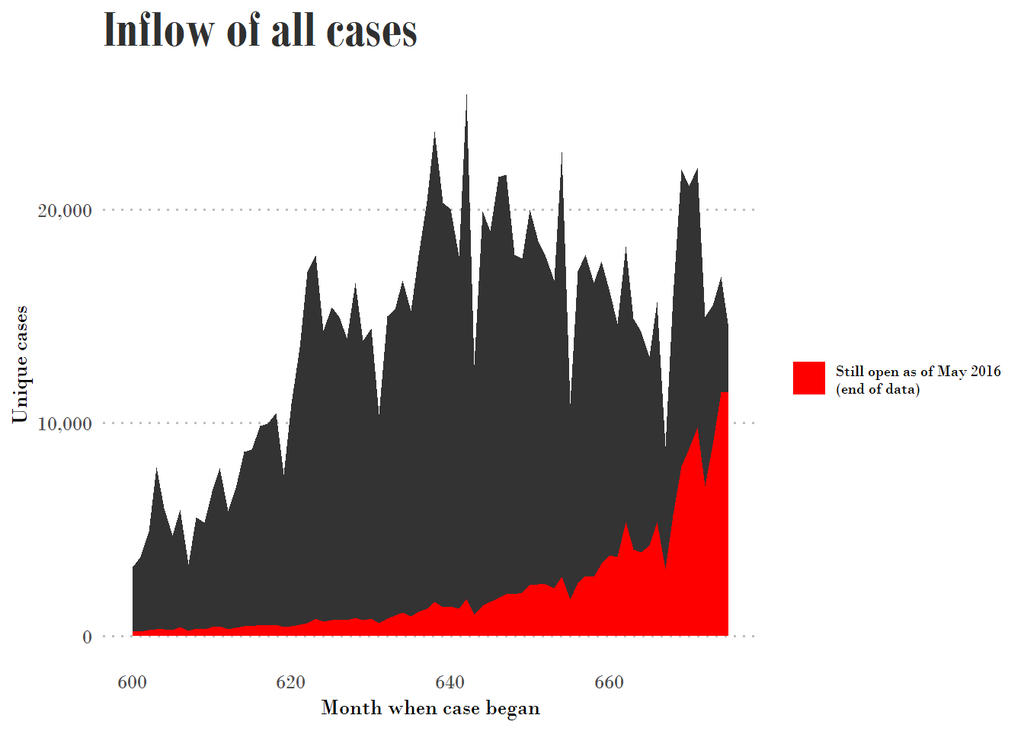

```r
data_nodupl %>%
  filter(y_beg >= 2010) %>%
  group_by(m_beg) %>%
  summarize(still_open_count = sum(still_open),
            all_count = n()) %>%
  ggplot() +
  geom_area(aes(m_beg, all_count), stat = "identity") +
  geom_area(aes(m_beg, still_open_count, fill = "red"), stat = "identity") +
  labs(title = "Inflow of all cases", x = "Month when case began", y = "Unique cases") +
  scale_fill_manual(name = "", values = "red", labels = "Still open as of May 2016\n(end of data)") +
  theme_evelina +
  scale_y_continuous(label = comma)
```

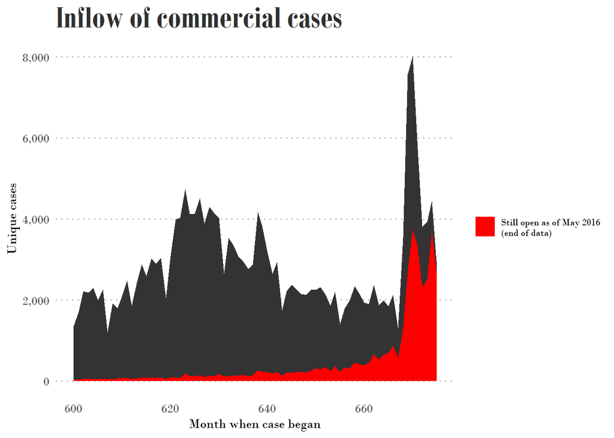

```r
data_nodupl %>%
  filter(y_beg >= 2010 & court_type == "2") %>%
  group_by(m_beg) %>%
  summarize(still_open_count = sum(still_open),
            all_count = n()) %>%
  ggplot() +
  geom_area(aes(m_beg, all_count), stat = "identity") +
  geom_area(aes(m_beg, still_open_count, fill = "red"), stat = "identity") +
  labs(title = "Inflow of commercial cases", x = "Month when case began", y = "Unique cases") +
  scale_fill_manual(name = "", values = "red", labels = "Still open as of May 2016\n(end of data)") +
  theme_evelina +
  scale_y_continuous(label = comma)
```

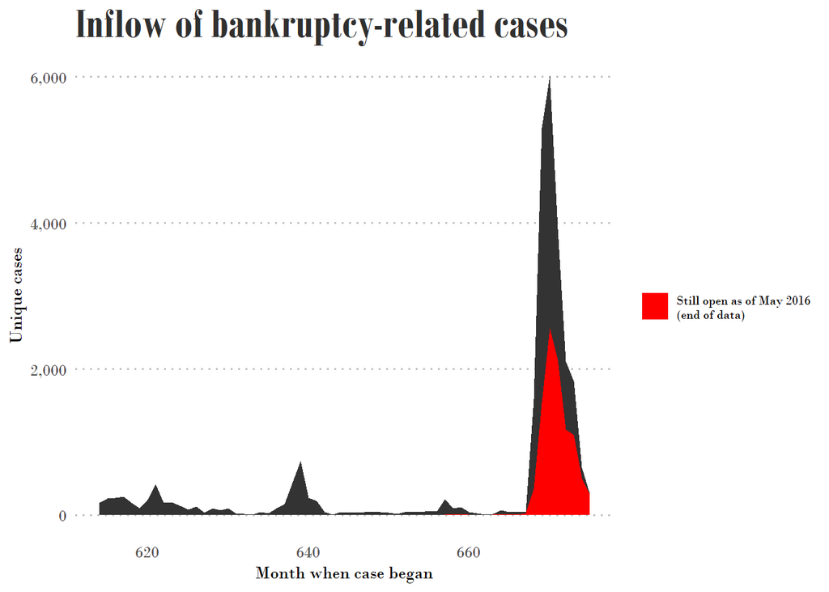

```r
data_bkpt %>%
  filter(y_beg >= 2010) %>%
  group_by(m_beg) %>%
  summarize(still_open_count = sum(still_open),
            all_count = n()) %>%
  ggplot() +
  geom_area(aes(m_beg, all_count), stat = "identity") +
  geom_area(aes(m_beg, still_open_count, fill = "red"), stat = "identity") +
  labs(title = "Inflow of bankruptcy-related cases", x = "Month when case began", y = "Unique cases") +
  scale_fill_manual(name = "", values = "red", labels = "Still open as of May 2016\n(end of data)") +
  theme_evelina +
  scale_y_continuous(label = comma)
```

## What do variables mean?

*Courts* Note: court_name and court_id are unique court identifiers

```r
data_nodupl %>%
  count(court_name, court_id) %>%
  arrange(desc(n))
```

```
## # A tibble: 104 x 3
##                               court_name court_id      n
##                                <dbl+lbl>    <dbl>  <int>
##  1   1 [Municipal Civil Court in Zagreb]      577 190402
##  2  80 [Commercial Court in Zagreb]            13 112868
##  3  50 [Municipal Court in Split]               7  54758
##  4 101 [Zagreb County Court]                    9  47030
##  5  42 [Municipal Court of Rijeka]              8  33555
##  6   3 [Municipal Labor Court in Zagreb]     5851  32409
##  7  77 [Commercial Court in Split]            114  27929
##  8  35 [Municipal Court of Osijek]           5107  27292
##  9  74 [Commercial Court in Rijeka]            17  25931
## 10  40 [Municipal Court in Pula - Pula]        21  23196
## # ... with 94 more rows
```

There are 104 courts overall that have been active since 2010Only 13 of those deal with commercial cases, and only 8 deal with bankruptcy (shortened proceedings) related cases *Idea: map courts on map, see if any geographical interpretation makes sense (like, areas with high population concentration and few courts are most overloaded…)*

```r
data_nodupl %>%
  filter(court_type == "2") %>%
  count(court_name, court_id) %>%
  arrange(desc(n))
```

```
## # A tibble: 13 x 3
##                                 court_name court_id      n
##                                  <dbl+lbl>    <dbl>  <int>
##  1 80 [Commercial Court in Zagreb]               13 112868
##  2 77 [Commercial Court in Split]               114  27929
##  3 74 [Commercial Court in Rijeka]               17  25931
##  4 72 [Commercial Court in Osijek]             5148  21180
##  5 78 [Commercial Court in VaraÃÂ¾din]          5152  16843
##  6 79 [Commercial Court in Zadar]                14   9815
##  7 69 [Commercial Court in Bjelovar]           5145   9372
##  8 73 [Commercial Court in Pazin]                18   3443
##  9 71 [Commercial court in Karlovac]           5147    288
## 10 75 [Commercial Court in Sisak]              5154    281
## 11 81 [Commercial Court in ÃÂ ibenik]           5151     53
## 12 76 [Commercial court in Slavonski Brod]     5150     40
## 13 70 [Commercial Court in Dubrovnik]          5146     37
```

```r
data_bkpt %>%
  count(court_name, court_id) %>%
  arrange(desc(n))
```

```
## # A tibble: 8 x 3
##                           court_name court_id     n
##                            <dbl+lbl>    <dbl> <int>
## 1 80 [Commercial Court in Zagreb]          13 11719
## 2 77 [Commercial Court in Split]          114  3716
## 3 72 [Commercial Court in Osijek]        5148  2838
## 4 74 [Commercial Court in Rijeka]          17  2772
## 5 78 [Commercial Court in VaraÃÂ¾din]     5152  2158
## 6 79 [Commercial Court in Zadar]           14  1956
## 7 73 [Commercial Court in Pazin]           18  1649
## 8 69 [Commercial Court in Bjelovar]      5145   778
```

Municipal courts deal with the highest number of cases. High commercial and supreme courts deal with less than 0.1% of all cases in the data. Only type 2 (commercial) courts deal with commercial and bankruptcy-related cases

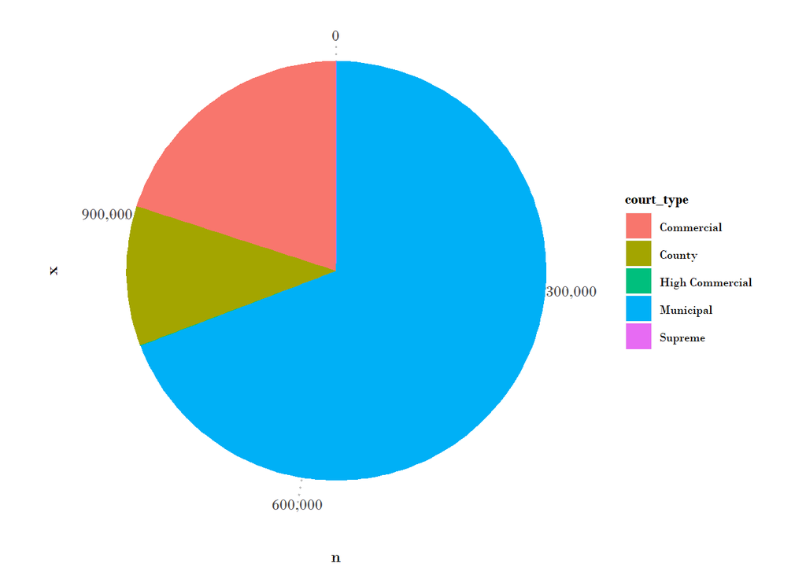

```r
#drop the label in case R misbehaves
#var_label(data_nodupl$court_type) <- NULL

data_nodupl %>%
  mutate(court_type = to_factor(court_type)) %>%
  count(court_type) %>%
  arrange(desc(n)) %>%
  mutate(court_type = as.character(court_type)) %>%
  ggplot(aes(x="", y = n, fill = court_type)) +
  geom_bar(width = 1, stat = "identity") +
  coord_polar("y", start = 0) +
  theme_evelina +
  scale_y_continuous(label = comma)
```

*Decision and procedure types* There are 318 decision types across all resolved cases, 25 across bankruptcy-related cases.

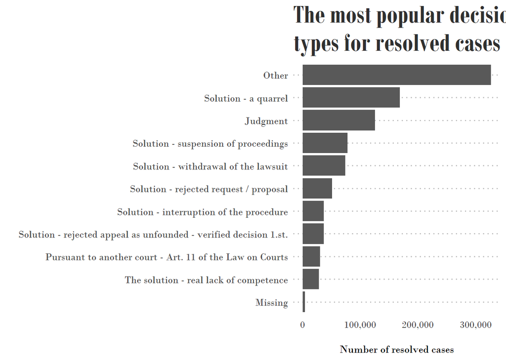

```r
data_nodupl %>%
  filter(still_open == 0) %>%
  mutate(decision_types = to_factor(decision_types),
         decision_types = fct_lump(decision_types, n = 9)) %>%
  count(decision_types) %>%
  mutate(decision_types = fct_explicit_na(decision_types, na_level = "Missing"),
         decision_types = fct_reorder(decision_types, n)) %>%
  ggplot() +
  geom_bar(aes(decision_types, n), stat = "identity") +
  coord_flip() +
  theme_evelina +
  scale_y_continuous(label = comma) +
  labs(x = "", y = "\nNumber of resolved cases", title = "The most popular decision\ntypes for resolved cases")
```

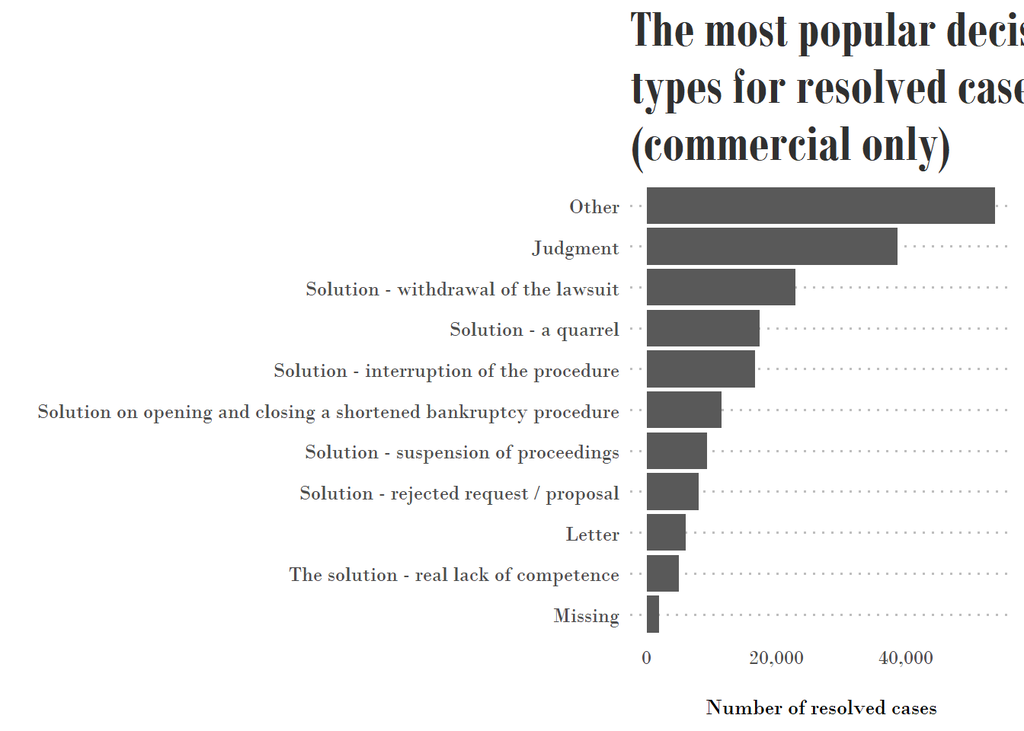

```r
data_nodupl %>%
  filter(still_open == 0 & court_type == 2) %>%
  mutate(decision_types = to_factor(decision_types)) %>%
  mutate(decision_types = fct_lump(decision_types, n = 9)) %>%
  count(decision_types) %>%
  mutate(decision_types = fct_explicit_na(decision_types, na_level = "Missing")) %>%
  mutate(decision_types = fct_reorder(decision_types, n)) %>%
  ggplot() +
  geom_bar(aes(decision_types, n), stat = "identity") +
  coord_flip() +
  theme_evelina +
  scale_y_continuous(label = comma) +
  labs(x = "", y = "\nNumber of resolved cases", title = "The most popular decision\ntypes for resolved cases\n(commercial only)")
```

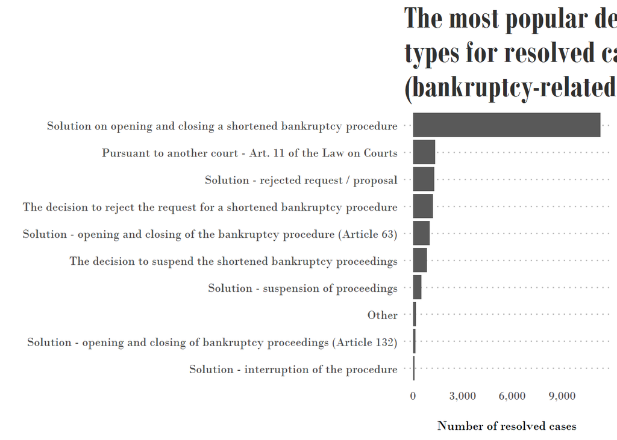

```r
data_bkpt %>%
  filter(still_open == 0) %>%
  mutate(decision_types = to_factor(decision_types)) %>%
  mutate(decision_types = fct_lump(decision_types, n = 9)) %>%
  count(decision_types) %>%
  mutate(decision_types = fct_explicit_na(decision_types, na_level = "Missing")) %>%
  mutate(decision_types = fct_reorder(decision_types, n)) %>%
  ggplot() +
  geom_bar(aes(decision_types, n), stat = "identity") +
  coord_flip() +
  theme_evelina +
  scale_y_continuous(label = comma) +
  labs(x = "", y = "\nNumber of resolved cases", title = "The most popular decision\ntypes for resolved cases\n(bankruptcy-related only)")
```

There are 35 procedure types among all cases and only one appears in procedure for bankruptcy-related cases.

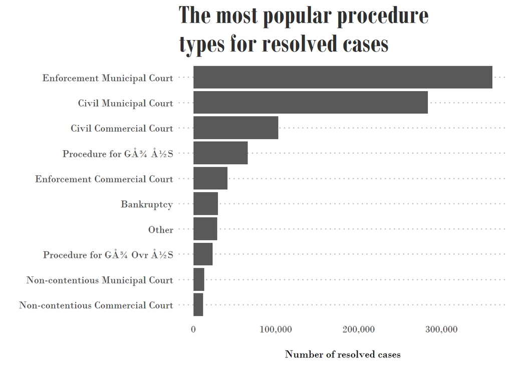

```r
data_nodupl %>%
  filter(still_open == 0) %>%
  mutate(procedure_types = to_factor(procedure_types),
         procedure_types = fct_lump(procedure_types, n = 9)) %>%
  count(procedure_types) %>%
  mutate(procedure_types = fct_explicit_na(procedure_types, na_level = "Missing"),
         procedure_types = fct_reorder(procedure_types, n)) %>%
  ggplot() +
  geom_bar(aes(procedure_types, n), stat = "identity") +
  coord_flip() +
  theme_evelina +
  scale_y_continuous(label = comma) +
  labs(x = "", y = "\nNumber of resolved cases", title = "The most popular procedure\ntypes for resolved cases")
```

[figure not shown]

```r
data_nodupl %>%
  filter(still_open == 0 & court_type == 2) %>%
  mutate(procedure_types = to_factor(procedure_types),
         procedure_types = fct_lump(procedure_types, n = 9)) %>%
  count(procedure_types) %>%
  mutate(procedure_types = fct_explicit_na(procedure_types, na_level = "Missing"),
         procedure_types = fct_reorder(procedure_types, n)) %>%
  ggplot() +
  geom_bar(aes(procedure_types, n), stat = "identity") +
  coord_flip() +
  theme_evelina +
  scale_y_continuous(label = comma) +
  labs(x = "", y = "\nNumber of resolved cases", title = "The most popular procedure\ntypes for resolved cases\n(commercial only)")
```

*Status* What is the difference between closed and archived and resolved? What does “changed register” vs. transferred mean?

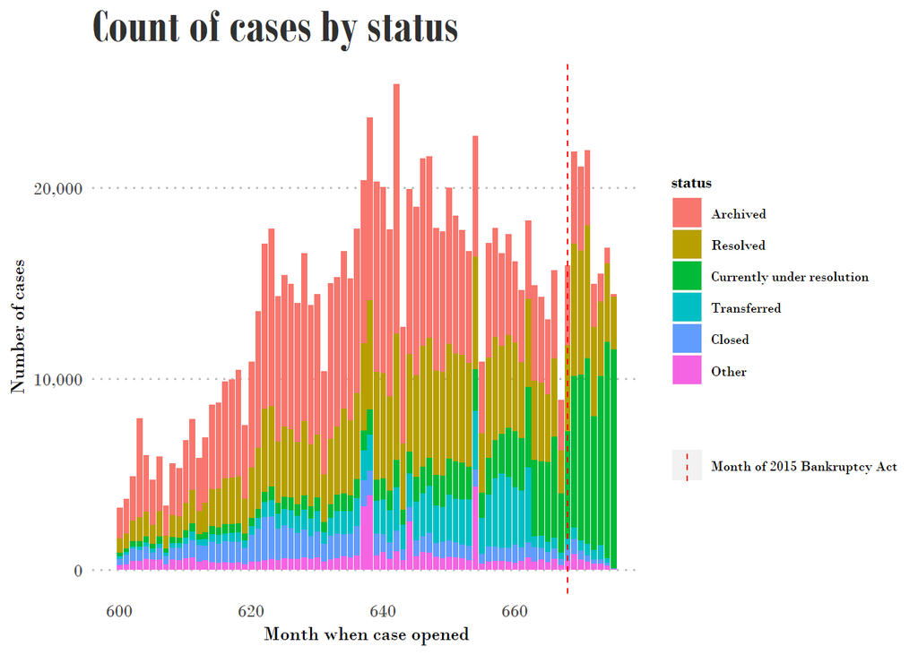

```r
data_nodupl %>%
  filter(y_beg >= 2010) %>%
  mutate(status = to_factor(status),
         status = fct_lump(status, n = 5)) %>%
  ggplot() +
  geom_bar(aes(m_beg, fill = status)) +
  theme_evelina +
  labs(title = "Count of cases by status", y = "Number of cases", x = "Month when case opened") +
  scale_y_continuous(label = comma) +
  geom_vline(aes(xintercept = 668, linetype = "dashed"), color = "red") +
  scale_linetype_manual(name = "",
                        values = "dashed", labels = "Month of 2015 Bankruptcy Act")
```

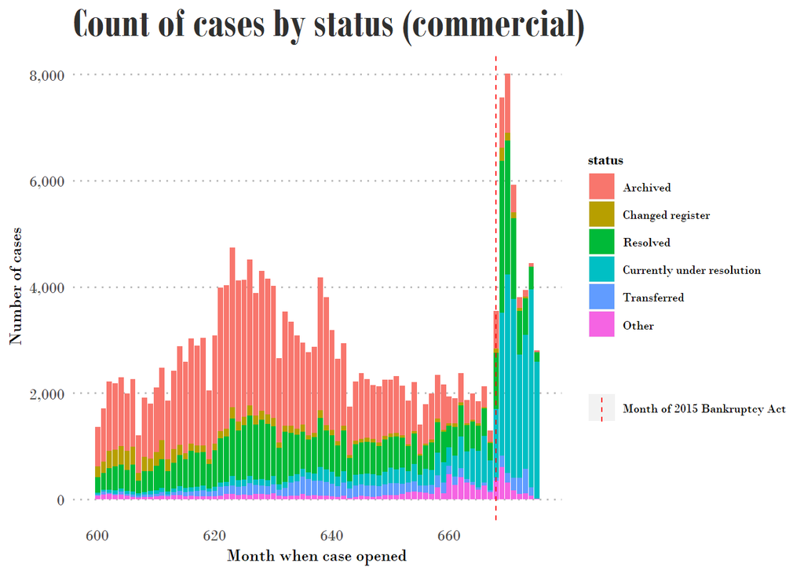

```r
data_nodupl %>%
  filter(y_beg >= 2010 & court_type == 2) %>%
  mutate(status = to_factor(status),
         status = fct_lump(status, n = 5)) %>%
  ggplot() +
  geom_bar(aes(m_beg, fill = status)) +
  theme_evelina +
  labs(title = "Count of cases by status (commercial)", y = "Number of cases", x = "Month when case opened") +
  scale_y_continuous(label = comma) +
  geom_vline(aes(xintercept = 668, linetype = "dashed"), color = "red") +
  scale_linetype_manual(name = "",
                        values = "dashed", labels = "Month of 2015 Bankruptcy Act")
```

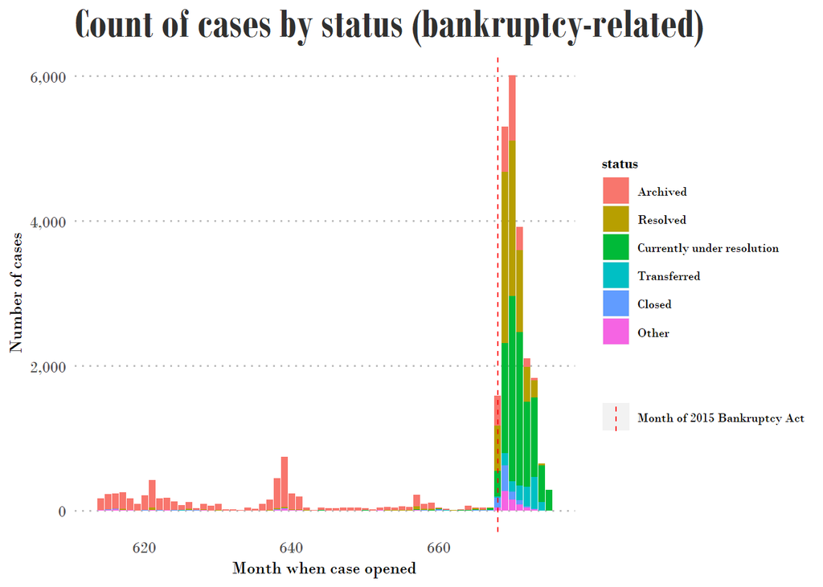

```r
data_bkpt %>%
  filter(y_beg >= 2010) %>%
  mutate(status = to_factor(status),
         status = fct_lump(status, n = 5)) %>%
  ggplot() +
  geom_bar(aes(m_beg, fill = status)) +
  theme_evelina +
  labs(title = "Count of cases by status (bankruptcy-related)", y = "Number of cases", x = "Month when case opened") +
  scale_y_continuous(label = comma) +
  geom_vline(aes(xintercept = 668, linetype = "dashed"), color = "red") +
  scale_linetype_manual(name = "",
                        values = "dashed", labels = "Month of 2015 Bankruptcy Act")
```

*Judges* There are 2,284 judge IDs overall that appear in this dataset and only 2,245 judge names.This means that up to about 2% judge names have multiple judge IDs corresponding to them (maybe these are different judges that just happen to have same names?). It might be safer to use the IDs, not names then.

```r
data_nodupl %>% count(assign_judge_id, assign_judge_name) %>% arrange(desc(n))
```

```
## # A tibble: 2,284 x 3
##    assign_judge_id assign_judge_name                      n
##              <dbl> <chr>                              <int>
##  1             695 "Ksenija ÃÂ imiÃ\u0087"             11711
##  2      1000002644 "Marina BlaÃÂ¾iÃ\u0087"              6227
##  3             165 Mirjana Chour HrÃÂ¡ak                6042
##  4      1000003104 Anna Preosti                        5879
##  5           19485 Marija RaguÃÂ¾                       5082
##  6             185 "Nada NekiÃ\u0087-Plevko"           4590
##  7             202 Zrinka Terlep                       4333
##  8           27347 "Ivana LovriÃ\u0087 VidaÃ\u008dek"  4326
##  9      1000001375 "Izabela BarbiÃ\u0087"              4174
## 10            3512 "Gordana MuÃÂ¾a AndreiÃ\u0087"       4055
## # ... with 2,274 more rows
```

```r
data_nodupl %>% count(assign_judge_id) %>% arrange(desc(n))
```

```
## # A tibble: 2,284 x 2
##    assign_judge_id     n
##              <dbl> <int>
##  1             695 11711
##  2      1000002644  6227
##  3             165  6042
##  4      1000003104  5879
##  5           19485  5082
##  6             185  4590
##  7             202  4333
##  8           27347  4326
##  9      1000001375  4174
## 10            3512  4055
## # ... with 2,274 more rows
```

```r
data_nodupl %>% count(assign_judge_name) %>% arrange(desc(n))
```

```
## # A tibble: 2,245 x 2
##    assign_judge_name                      n
##    <chr>                              <int>
##  1 "Ksenija ÃÂ imiÃ\u0087"             11711
##  2 "Marina BlaÃÂ¾iÃ\u0087"              6227
##  3 Mirjana Chour HrÃÂ¡ak                6042
##  4 Anna Preosti                        5879
##  5 Marija RaguÃÂ¾                       5082
##  6 "Nada NekiÃ\u0087-Plevko"           4590
##  7 Zrinka Terlep                       4333
##  8 "Ivana LovriÃ\u0087 VidaÃ\u008dek"  4326
##  9 "Izabela BarbiÃ\u0087"              4174
## 10 "Gordana MuÃÂ¾a AndreiÃ\u0087"       4055
## # ... with 2,235 more rows
```

Only 132 judges have worked on bankruptcy-related cases, shortened proceedings. As bankruptcy-related cases inflow surged in the wake of the 2015 Bankruptcy Act, more unique judges had bankruptcy-related cases assigned to them - a perfectly intuitive result.

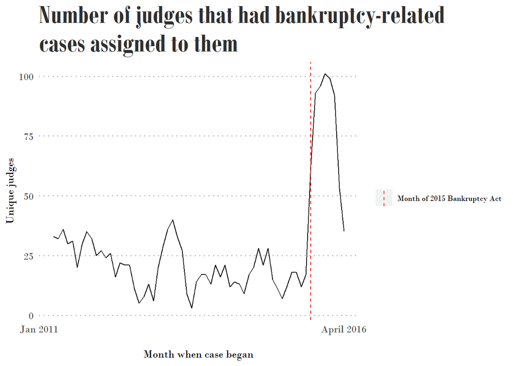

```r
data_bkpt %>%
  count(m_beg, assign_judge_id) %>%
  count(m_beg) %>%
  ggplot() +
  geom_line(aes(m_beg, n, group = 1)) +
  theme_evelina +
  labs(title = "Number of judges that had bankruptcy-related\ncases assigned to them",
       x = "\nMonth when case began", y = "Unique judges") +
  scale_x_continuous(breaks = c(611, 675),
                   labels = c("Jan 2011", "April 2016")) +
  geom_vline(aes(xintercept = 668, linetype = "dashed"), color = "red") +
  scale_linetype_manual(name = "",
                        values = "dashed", labels = "Month of 2015 Bankruptcy Act")
```